# Adult Data Machine Learning Analysis

6/5/2017

In this project, I furthur investigate the models using supervised learning and unsupervised learning.

Before moving into supervised learning, I save the train and test data from last project as csv file, so that it is easier to be loaded into h2o package.

```r
#write.csv(train, file = "~/Desktop/train.csv", row.names = F)
#write.csv(test, file = "~/Desktop/test.csv", row.names = F)
```

### Part1: Neural Network

Unlike the neural networks of the past, modern Deep Learning provides training stability, generalization, and scalability with big data. Since it performs quite well in a number of diverse problems, Deep Learning is quickly becoming the algorithm of choice for the highest predictive accuracy.

In deep learning algorithm, there exist 3 layers: input layer, hidden layer and output layer. It works as follows, At first, feed data to input layer. It then transmits the data to hidden layer. These hidden layer comprises of neurons. These neurons uses some function and assist in mapping non-linear relationship among the variables.The hidden layers are user specified. Finally, these hidden layers delivers the output to output layer which then gives out the result.

```r
library(h2o)
h2o.init(nthreads=-1, max_mem_size="2G")
h2o.removeAll()
train.1 <- h2o.importFile(path = normalizePath("../Desktop/train.csv"))
test.1  <- h2o.importFile(path = normalizePath("../Desktop/test.csv"))
set.seed(1234567)
dx_split <- h2o.splitFrame(test.1, ratios = 0.5, seed = 123)
valid.1 <- dx_split[[1]]
test.1 <- dx_split[[2]]
```

- H2O’s Deep Learning Architecture:

  H2O’s Deep Learning functionalities include:
1. optional specification of learning rate, annealing, and momentum options
2. regularization options such as L1, L2 and model averaging to prevent model overfitting
3. grid search for hyperparameter optimization and model selection
4. automatic early stopping based on convergence of user-specified metrics to user-specified tolerance
5. model checkpointing for reduced run times and model tuning

   H2o’s important parameters meaning:
6. hidden: Number of hidden layers and number of neurons in each layer in the architechture.
7. epochs: Number of iterations to be done on the data set.
8. activation: Type of activation function to use. In h2o, the major activation functions are Tanh, Rectifier, and Maxout. 4.l1 and l2: regularization, add stability and improve generalization, cases many weights to become 0.
9. momentum: Add a fraction of previous update to current one. When the gradient keeps pointing in the same direction, this will increase the size of the steps taken towards the minimum, and this will reduce global learning rate when using a lot of momentum

```r
#set variables
y <- "salary_level"
x <- setdiff(colnames(train.1),y)
```

```r
#train the model - without hidden layer
system.time({
deepmodel <- h2o.deeplearning(x = x
                            ,y = y
                            ,training_frame = train.1
                            , validation_frame = valid.1
                            ,standardize = T
                            ,model_id = "deep_model"
                            ,activation = "Rectifier"
                            ,epochs = 100
                            ,stopping_rounds = 2
                            , stopping_metric = "AUC"
                            , stopping_tolerance = 0
                            ,variable_importances = T)
})
```

```
##    user  system elapsed
##   0.711   0.039  45.666
```

I use system.time() for calculatiing the total time of running the model. First two entries are the total user and system CPU times of the current process and any child processes on which it has waited, and third entry is the real elapsed time since the process was started. Thus, this model takes real time around 45 seconds.

Following plot shows the variable importance of the data. It seems like male, capital gain, United States, married with spouse, and white people are the most important variables from Adult dataset that they have more earning than others.

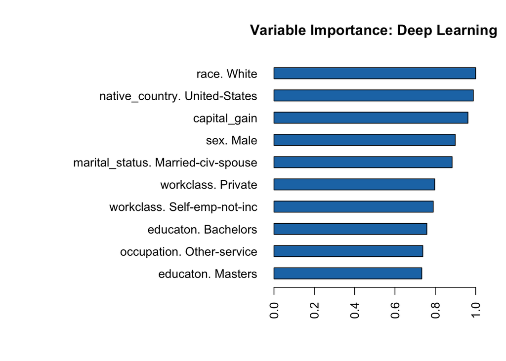

```r
h2o.varimp_plot(deepmodel)
```

```r
h2o.confusionMatrix(deepmodel)
```

```
## Confusion Matrix (vertical: actual; across: predicted)  for max f1 @ threshold = 0.463985729155726:
##         <=50K  >50K    Error         Rate
##  <=50K   6692   903 0.118894    =903/7595
##  >50K     544  1950 0.218123    =544/2494
## Totals   7236  2853 0.143424  =1447/10089
```

```r
h2o.performance(deepmodel)@metrics$AUC #AUC Rate
```

```
## [1] 0.9254119
```

Make prediction using test data:

```r
deep.pred = h2o.predict(deepmodel, newdata = test.1)
```

Calculate accuracy rate:

```r
Accuracy <- deep.pred$predict ==  test.1$salary_level

mean(Accuracy)
```

```
## [1] 0.8399466
```

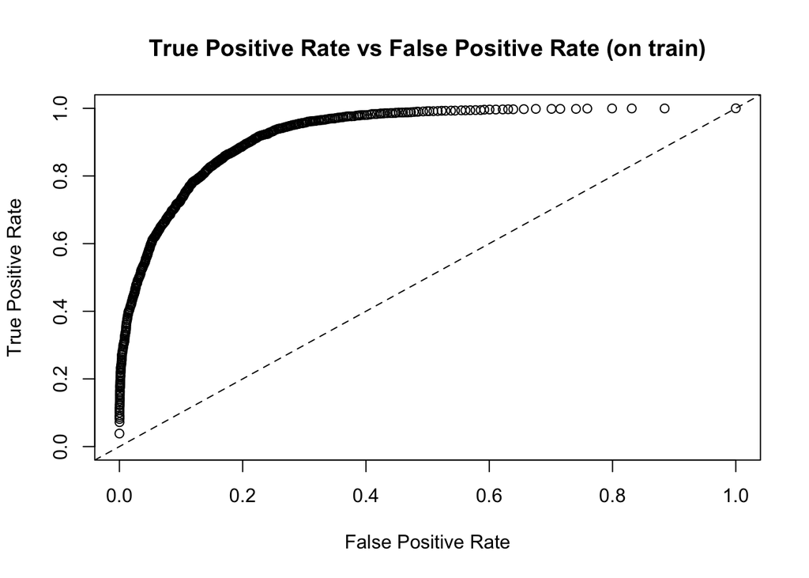

```r
plot(h2o.performance(deepmodel), type = "roc")
```

The AUC rate is 92%, and ROC curve shows the model good fitting. The model is pretty good.

Now I try some other models of deep learning with changing other parameters:

To keep it fast, I try to run for one ephoch (one pass over the training data).

```r
system.time({
m1       <- h2o.deeplearning(x = x
                            ,y = y
                            ,training_frame = train.1
                            , validation_frame = valid.1
                            #,standardize = T
                            ,model_id = "m1"
                            ,activation = "Rectifier"
                            ,epochs = 1
                            ,variable_importances = T)

})
```

```
##    user  system elapsed
##   0.361   0.012   7.678
```

Early Stopping:

stopping_metric: use as stopping criterion stopping_tolerance and stopping_rounds: training stops when the the stopping metric does not improve by the stopping tolerance proportion any more for the number of consecutive rounds defined by stopping rounds.

I run another, smaller network, and I let it stop automaticallt once the AUC rate converages.

```r
system.time({
m2       <- h2o.deeplearning(x = x
                            ,y = y
                            ,training_frame = train.1
                            , validation_frame = valid.1
                            ,standardize = T
                            ,model_id = "m2"
                            ,hidden = c(32,32,32)
                            ,activation = "Rectifier"
                            ,epochs = 100
                            ,stopping_rounds = 2
                            , stopping_metric = "AUC"
                            , stopping_tolerance = 0
                            ,variable_importances = T)

})
```

```
##    user  system elapsed
##   0.494   0.019  23.163
```

It takes around 24 seconds.

Tunning:

With some tuning, it is possible to obtain the model with error rate of below 10% with large models.

Add input drop out ratio:

```r
system.time({
  m4 <-      h2o.deeplearning(x = x
                            ,y = y
                            ,training_frame = train.1
                            , validation_frame = valid.1
                            ,activation = "Rectifier"
                            , hidden = c(50,50,50,50)
                            , input_dropout_ratio = 0.2
                            ,epochs = 100
                            , stopping_rounds = 2
                            , stopping_metric = "AUC"
                            , stopping_tolerance = 0)
})
```

```
##    user  system elapsed
##   0.575   0.026  32.257
```

```r
h2o.performance(m4, test.1)@metrics$AUC
```

```
## [1] 0.9119808
```

AUC rate is 91% with the running time of 32 seconds.

Exclude input drop out ratio:

```r
system.time({
  m5 <-     h2o.deeplearning(x = x
                            ,y = y
                            ,training_frame = train.1
                            , validation_frame = valid.1
                            ,activation = "Rectifier"
                            , hidden = c(50,50,50,50)
                            ,epochs = 100, stopping_rounds = 2, stopping_metric = "AUC", stopping_tolerance = 0)
})
```

```
##    user  system elapsed
##   0.529   0.023  26.096
```

```r
h2o.performance(m5, test.1)@metrics$AUC
```

```
## [1] 0.9107515
```

AUC rate does not improve, and hence input drop out ratio does not impact heavily on the model.

Change hidden layer:

```r
system.time({
  m6 <-     h2o.deeplearning(x = x
                            ,y = y
                            ,training_frame = train.1
                            , validation_frame = valid.1
                            ,activation = "Rectifier"
                            ,hidden = c(20,20)
                            , epochs = 100, stopping_rounds = 2, stopping_metric = "AUC", stopping_tolerance = 0)
})
```

```
##    user  system elapsed
##   0.439   0.014  16.832
```

```r
h2o.performance(m6, test.1)@metrics$AUC
```

```
## [1] 0.9062519
```

With faster speed, this model has slightly lower AUC rate.

Make hidden layer simple:

```r
system.time({
  m7 <-     h2o.deeplearning(x = x
                            ,y = y
                            ,training_frame = train.1
                            , validation_frame = valid.1
                            ,activation = "Rectifier", hidden = c(20),
            epochs = 100, stopping_rounds = 2, stopping_metric = "AUC", stopping_tolerance = 0)
})
```

```
##    user  system elapsed
##   0.414   0.013  12.885
```

```r
h2o.performance(m7, test.1)@metrics$AUC
```

```
## [1] 0.9060483
```

With faster speed, AUC rate has no improve. Hidden layer cannot be too simple for this data.

Define hidden layer as 200, and add regularization l1 and l2 to the model. L1 lets only strong weights survive, while L2 prevents any single weight from getting too big:

```r
system.time({
  m9 <-     h2o.deeplearning(x = x
                            ,y = y
                            ,training_frame = train.1
                            , validation_frame = valid.1
                            ,activation = "Rectifier", hidden = c(200,200), l1 = 1e-5, l2 = 1e-5,
            epochs = 100, stopping_rounds = 2, stopping_metric = "AUC", stopping_tolerance = 0)
})
```

```
##    user  system elapsed
##   0.685   0.031  43.570
```

```r
h2o.performance(m9, test.1)@metrics$AUC
```

```
## [1] 0.9081036
```

With more time, AUC not improve.

Drop regulartization, add adaptive rate as false (default is true):

```r
system.time({
  m10 <- h2o.deeplearning(x = x
                            ,y = y
                            ,training_frame = train.1
                            , validation_frame = valid.1
                            ,activation = "Rectifier", hidden = c(200,200),
            adaptive_rate = FALSE, ## default: rate = 0.005, rate_decay = 1, momentum_stable = 0,
            epochs = 100, stopping_rounds = 2, stopping_metric = "AUC", stopping_tolerance = 0)
})
```

```
##    user  system elapsed
##   0.792   0.037  55.712
```

```r
h2o.performance(m10, test.1)@metrics$AUC
```

```
## [1] 0.909814
```

Add momentum:

```r
system.time({
  m11 <-h2o.deeplearning(x = x
                            ,y = y
                            ,training_frame = train.1
                            , validation_frame = valid.1,
            activation = "Rectifier", hidden = c(200,200),
            adaptive_rate = FALSE, rate = 0.001, momentum_start = 0.5, momentum_ramp = 1e5, momentum_stable = 0.99,
            epochs = 100, stopping_rounds = 2, stopping_metric = "AUC", stopping_tolerance = 0)
})
```

```
##    user  system elapsed
##   1.179   0.059  93.709
```

```r
h2o.performance(m11, test.1)@metrics$AUC
```

```
## [1] 0.9081188
```

AUC rate does not improve.

Change the rate from 0.001 to 0.01:

```r
system.time({
  m12 <- h2o.deeplearning(x = x
                            ,y = y
                            ,training_frame = train.1
                            , validation_frame = valid.1,
            activation = "Rectifier", hidden = c(200,200),
            adaptive_rate = FALSE, rate = 0.01, momentum_start = 0.5, momentum_ramp = 1e5, momentum_stable = 0.99,
            epochs = 100, stopping_rounds = 2, stopping_metric = "AUC", stopping_tolerance = 0)
})
```

```
##    user  system elapsed
##   0.610   0.028  35.603
```

```r
h2o.performance(m12, test.1)@metrics$AUC
```

```
## [1] 0.9106169
```

This model’s AUC rate improves to 91% which is better.

```r
system.time({
m3 <-       h2o.deeplearning(x = x
                            ,y = y
                            ,training_frame = train.1
                            , validation_frame = valid.1
                            ,standardize = T
                            ,model_id = "dm_tuned"
                            ,activation = "Rectifier"
                            ,hidden = c(128,128,128)
                           ,adaptive_rate = F
                           ,rate = 0.01
                           ,rate_annealing = 2e-6
                           ,momentum_start = 0.2
                           ,momentum_stable = 0.4
                           ,momentum_ramp = 1e7
                           ,l1=1e-5
                           ,l2=1e-5
                            ,epochs = 100
                            ,stopping_rounds = 2
                            , stopping_metric = "AUC"
                            , stopping_tolerance = 0
                            ,variable_importances = T)

})
```

```
##    user  system elapsed
##   0.674   0.030  41.732
```

```r
h2o.performance(m1)@metrics$AUC
```

```
## [1] 0.9125846
```

```r
h2o.performance(m2)@metrics$AUC
```

```
## [1] 0.9207607
```

```r
h2o.performance(m3)@metrics$AUC
```

```
## [1] 0.919291
```

```r
# Calculate performance measures at threshold that maximizes precision
m1.pred = h2o.predict(m1, newdata = test.1)
m2.pred = h2o.predict(m2, newdata = test.1)
m3.pred = h2o.predict(m3, newdata = test.1)
m4.pred = h2o.predict(m4, newdata = test.1)
m5.pred = h2o.predict(m5, newdata = test.1)
m6.pred = h2o.predict(m6, newdata = test.1)
m7.pred = h2o.predict(m7, newdata = test.1)
m9.pred = h2o.predict(m9, newdata = test.1)
m10.pred = h2o.predict(m10, newdata = test.1)
m11.pred = h2o.predict(m11, newdata = test.1)
m12.pred = h2o.predict(m12, newdata = test.1)
```

Calculate accuracy rate:

```r
m1.a <- m1.pred$predict ==  test.1$salary_level
m2.a <- m2.pred$predict ==  test.1$salary_level
m3.a <- m3.pred$predict ==  test.1$salary_level
m4.a <- m4.pred$predict ==  test.1$salary_level
m5.a <- m5.pred$predict ==  test.1$salary_level
m6.a <- m6.pred$predict ==  test.1$salary_level
m7.a <- m7.pred$predict ==  test.1$salary_level
m9.a <- m9.pred$predict ==  test.1$salary_level
m10.a <- m10.pred$predict ==  test.1$salary_level
m11.a <- m11.pred$predict ==  test.1$salary_level
m12.a <- m12.pred$predict ==  test.1$salary_level

mean(m1.a);mean(m2.a);mean(m3.a);mean(m4.a);mean(m5.a);mean(m6.a);mean(m7.a);mean(m9.a);mean(m10.a) ;mean(m11.a) ;mean(m12.a)
```

```
## [1] 0.8321663
```

```
## [1] 0.8340558
```

```
## [1] 0.8386129
```

```
## [1] 0.8363899
```

```
## [1] 0.8346115
```

```
## [1] 0.8208292
```

```
## [1] 0.8332778
```

```
## [1] 0.8377237
```

```
## [1] 0.8244971
```

```
## [1] 0.8298322
```

```
## [1] 0.8279426
```

##### Hyper-parameter Tuning with Grid Search

Since there are a lot of parameters that can impact model accuracy, hyper-parameter tuning is especially important for Deep Learning.I use the simplest hyperparameter search method which is a brunte-force scan of the full Cartesian product of all combinations specified by a grid search.

First, I set the hyper parameters.

```r
hyper_params <- list(
  activation = c("Rectifier","Tanh","Maxout"),
  epochs = c(10,50, 100 ),
  hidden = list(c(128,128,128), c(200,200,200)),
  rate = c(0.01, 0.001),
  rate_annealing = c(1e-8, 2e-6),
  momentum_start = c(0.2, 0.5),
  momentum_stable = c(0.99, 0.4),
  l1 = seq(0, 1e-4,1e-6),
  l2 = seq(0, 1e-4, 1e-6))
```

Then, I define the search criteria.

```r
search_criteria = list(strategy = "RandomDiscrete",
                       max_runtime_secs = 360,
                       max_models = 100,
                       seed = 1234567,
                       stopping_rounds =5,
                       stopping_metric = "AUC"
              , stopping_tolerance = 0
                       )
```

Now, I train the model with combinations of hyper-parameters from specified stopping criteria and hyper-parameter grid:

```r
system.time({
dl_random_grid <- h2o.grid(
  algorithm = "deeplearning",
  grid_id = "grid_random",
  training_frame = train.1,
  validation_frame = valid.1,
  nfolds = 5,
  x = x,y = y,
  momentum_ramp = 1e7,
  variable_importances = T,
  adaptive_rate = F,
  max_w2 = 10, #improve stability for Rectifier
  hyper_params = hyper_params,
  search_criteria = search_criteria
)
})
```

```
##    user  system elapsed
##   3.553   0.221 378.406
```

```r
grid <- h2o.getGrid("grid_random", sort_by = "AUC",
                    decreasing = FALSE)

best_model <- h2o.getModel(grid@model_ids[[1]])
```

Then, I perform confusion matrix and pick the best regularization parameters:

```r
h2o.confusionMatrix(best_model, valid =T)
```

```
## Confusion Matrix (vertical: actual; across: predicted)  for max f1 @ threshold = 0.218036929486493:
##         <=50K  >50K    Error        Rate
##  <=50K   5551  1230 0.181389  =1230/6781
##  >50K     396  1915 0.171354   =396/2311
## Totals   5947  3145 0.178839  =1626/9092
```

```r
best_params <- best_model@allparameters
best_params$l1
```

```
## [1] 9.8e-05
```

```r
best_params$l2
```

```
## [1] 2.1e-05
```

Calculate the AUC rate and Accuracy rate:

```r
h2o.auc(h2o.performance(best_model, newdata = test.1))
```

```
## [1] 0.907824
```

```r
best.pred = h2o.predict(best_model, newdata = test.1)
best.a <- best.pred$predict ==  test.1$salary_level
mean(best.a)
```

```
## [1] 0.8221629
```

#### Part2: hyperparameter optimization for GBM with random research

In the previous project, I tried hyperparameter search for GBM using XBOOST package, and this time I use h2o package with h2o.grid function to do random search.

Most of the times, hyperparameter search for more than 4 parameters can be done more efficiently with random parameter search than with grid search. I simply build up to max_models models with parameters drawn randomly from user-specified distributions. In general, metric-based early stopping optionally combined with max runtime is the best choice. The number of models will take to converge toward a global best can vary a lot, and metric-based early stopping accounts for this automatically by stopping the search process when the error curve flattens out.

First, construct a large Cartesian hyper-parameter space.

```r
ntrees_opts = c(1000)
max_depth_opts = seq(1,20)
min_rows_opts = c(1,5,10,20,50,100)
learn_rate_opts = seq(0.001,0.01,0.001)
sample_rate_opts = seq(0.1,1,0.05)
col_sample_rate_opts = seq(0.1,1,0.05)
col_sample_rate_per_tree_opts = seq(0.1,1,0.05)
nbins_cats_opts = seq(100,1000,100)
```

List hyper parameters:

```r
hyper_params = list( ntrees = ntrees_opts,
                     max_depth = max_depth_opts,
                     min_rows = min_rows_opts,
                     learn_rate = learn_rate_opts,
                     sample_rate = sample_rate_opts,
                     col_sample_rate = col_sample_rate_opts,
                     col_sample_rate_per_tree = col_sample_rate_per_tree_opts
                     ,nbins_cats = nbins_cats_opts
)
```

Then, search a random subset of these hyper-parameters.

```r
search_criteria = list(strategy = "RandomDiscrete",
                       max_runtime_secs = 600,
                       max_models = 100,
                       stopping_metric = "AUC",
                       stopping_tolerance = 0.00001,
                       stopping_rounds = 3,
                       seed = 123456)
```

Now I train the model with combinations of hyper-parameters:

```r
#set variables
y <- "salary_level"
x <- setdiff(colnames(train.1),y)

system.time({
gbm_grid <- h2o.grid("gbm",
                     grid_id = "mygrid",
                       training_frame = train.1,
                     validation_frame = valid.1,
                      x = x,y = y,
                      nfolds = 5,
                     distribution = "bernoulli",
                     stopping_rounds = 2,
                     stopping_tolerance = 1e-3,
                     stopping_metric = "AUC",
                     score_tree_interval = 100,
                     seed = 123456,
                     hyper_params = hyper_params,
                     search_criteria = search_criteria)
})
```

```r
gbm_sorted_grid <- h2o.getGrid(grid_id = "mygrid", sort_by = "AUC")

best_model <- h2o.getModel(gbm_sorted_grid@model_ids[[1]])

h2o.auc(h2o.performance(best_model, newdata = test.1))
```

```
## [1] 0.9159206
```

```r
best.pred = h2o.predict(best_model, newdata = test.1)
best.a <- best.pred$predict ==  test.1$salary_level
mean(best.a)
```

```
## [1] 0.8333889
```

```r
#h2o.shutdown(prompt=FALSE)
```

#### Part3: Support Vector Machine

The Support Vector Machine constructs set of hyperplanes in a high dimensional space, which can be used for classification. Intuitively, a good separation is achieved by the hyperplane that has the largest distance to the nearest training- data point of any class, since in general the larger the margin the lower the generalization error of the classifier.

In order to train the model with SVM, I use e1071 package. I want my train and test data to be sparse matrix with same number of columns, and I use rbind function to combine the data, transform to matrix, and then seperate the data with same row numbers.

```r
library(e1071)
library(pROC)
library(ROCR)
test = read.csv("~/Desktop/test.csv")
train = read.csv("~/Desktop/train.csv")

x = rbind(train,test)
X <- Matrix::sparse.model.matrix(salary_level ~ . -1, data = x)

X_train <- X[1:27133,] #original train data of sparse model matrix
X_test <- X[-c(1:27133),] # original test data of sparse model matrix

system.time({
  md <- svm(x = X_train, y = as.factor(train$salary_level), probability= TRUE)
})
```

```
##    user  system elapsed
## 304.625   1.644 309.178
```

The real time costs more than 5 minutes.

Then, apply this model to test data and calculate AUC and accuracy rate:

```r
phat <- attr(predict(md, newdata = X_test, probability = TRUE), "probabilities")[,2]
p= predict(md, newdata = X_test, probability = TRUE)

rocr_pred <- prediction(phat, test$salary_level)
performance(rocr_pred, "auc")@y.values[[1]]
```

```
## [1] 0.8888439
```

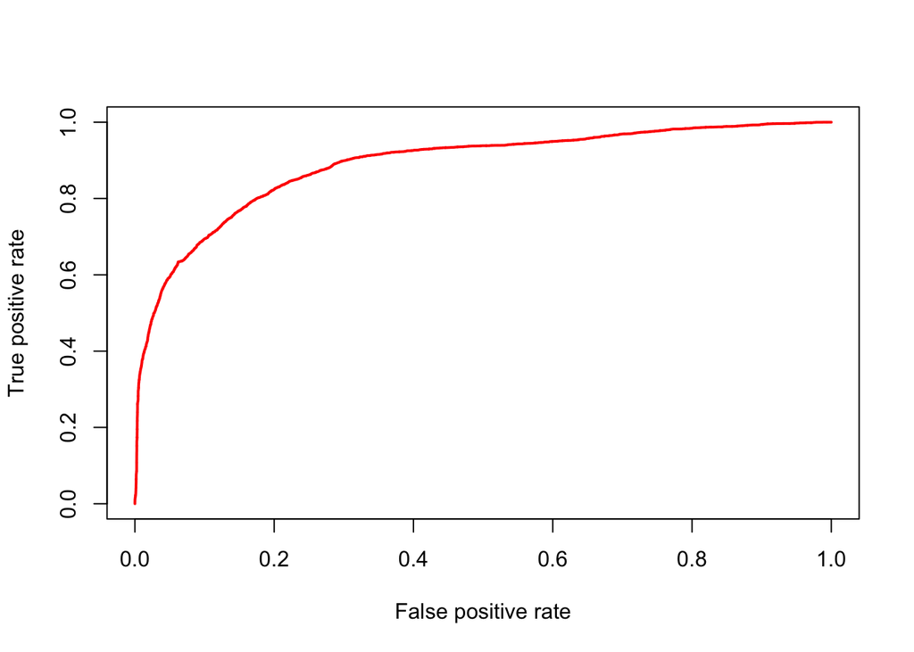

```r
perf = performance(rocr_pred ,"tpr","fpr")
plot(perf,col=2,lwd=2)
```

The ROC plot has the line close to top left.

```r
caret::confusionMatrix(test$salary_level, predict(md, newdata = X_test, probability = TRUE))
```

```
## Confusion Matrix and Statistics
##
##           Reference
## Prediction  <=50K  >50K
##      <=50K  12936   598
##      >50K    1918  2637
##
##                Accuracy : 0.8609
##                  95% CI : (0.8558, 0.8659)
##     No Information Rate : 0.8212
##     P-Value [Acc > NIR] : < 2.2e-16
##
##                   Kappa : 0.5916
##  Mcnemar's Test P-Value : < 2.2e-16
##
##             Sensitivity : 0.8709
##             Specificity : 0.8151
##          Pos Pred Value : 0.9558
##          Neg Pred Value : 0.5789
##              Prevalence : 0.8212
##          Detection Rate : 0.7151
##    Detection Prevalence : 0.7482
##       Balanced Accuracy : 0.8430
##
##        'Positive' Class :  <=50K
##
```

From the result, this model has the accuracy rate of 86%, AUC rate is around 90%.

### Part4: K-Nearest Neighbor

KNN stands for K-Nearest Neighbor algorithm it makes use of Euclidean distance to calculate distance of points from existing data points.

Since KNN requires all numeric fields except the dependent variable I convert the independent variables into numeric wherever required as following:

```r
library(class)
train.2 = train
test.2 = test
features = names(train.2)
for (f in features) {
  if (class(train.2[[f]])=="factor") {
    levels <- unique(train.2[[f]])
    train.2[[f]] <- as.numeric(as.integer(factor(train.2[[f]], levels=levels)))
  }
}

for (f in features) {
  if (class(test.2[[f]])=="factor") {
    levels <- unique(test.2[[f]])
    test.2[[f]] <- as.numeric(as.integer(factor(test.2[[f]], levels=levels)))
  }
}
```

Then, I apply KNN function in class package to train the model.

```r
system.time({
knn_pred<-knn(train.2[,-13],test.2[,-13],train.2[,13],9)
})
```

```
##    user  system elapsed
##   7.359   0.036   7.430
```

```r
caret::confusionMatrix(test.2[,13], knn_pred, mode = "prec_recall")
```

```
## Confusion Matrix and Statistics
##
##           Reference
## Prediction     1     2
##          1 12532  1002
##          2  2361  2194
##
##                Accuracy : 0.8141
##                  95% CI : (0.8083, 0.8197)
##     No Information Rate : 0.8233
##     P-Value [Acc > NIR] : 0.9994
##
##                   Kappa : 0.4524
##  Mcnemar's Test P-Value : <2e-16
##
##               Precision : 0.9260
##                  Recall : 0.8415
##                      F1 : 0.8817
##              Prevalence : 0.8233
##          Detection Rate : 0.6928
##    Detection Prevalence : 0.7482
##       Balanced Accuracy : 0.7640
##
##        'Positive' Class : 1
##
```

```r
pred.2 <- prediction(as.numeric(knn_pred), as.numeric(test[,13]))
performance(pred.2, "auc")@y.values[[1]]
```

```
## [1] 0.7038164
```

Model accuracy rate is 81%, and AUC is 70%.

### Part5: Model Compare and Conclusion

In this project, I use H2O package for deep learning and GBM. H2O contains good default values for many datasets, but to get the best performance, it is better to tune some hyperparameters to maximize the predictive performance. For Hyper Parameter Optimization, I try both grid search and random search. Grid search is searching through a manually specified subset of the hyperparameter space of a learning algorithm, and it must be guided by some performance metric. Therefore, grid search is potentially expensive method, while randomized search is more effective in high-dimensional spaces. Random search becomes more efficient method for training the model.

Moreover, I try SVM and KNN method. KNN is fast in speed, but low predictive performance. KNN is a supervised lazy classifier, making it difficult to use for prediction in real time. When solving a problem that find similarity between observations, KNN can be better. KNN is most likely to overfit, and hence adjusting number of k to maximise test set performance is a cost.

SVM is slow in speed, and medium predictive performance compared to H2o package. SVM efficiently performs non-linear classification, implicitly mapping inputs into high-dimensional feature spaces. With fewer hyperparameters, training a model can be easier but time needed.

Random Forest is a traditional learning method. Random Forests train each tree independently, and thus the model becomes more robust, and less likely to overfit on the training data. Additionally, Random Forest is much easier to train since it has two tuning parameters mtry and ntrees. However, time cost is heavy to train the model. Thus, random forest will be a good choice of simple data.

Xgboost is used in last project. Unlike Random Forests, xgboost can’t simply build the trees in parallel but builds the tree itself in a parallel order. xgboost has faster training speed with higher efficiency, and also guarantee the better accuracy with parallel learning supported. Moreover, xgboost is capable of handling large-scale data. When training a model with high dimensional data, random forest has slower speed and lower predictive performance than xgboost.

Combined with the models from previous project, model with H2o package such as deep learning and hyper parameter optimization performs well on adult data, but not time efficient. Among hyper parameter optimization, random search is a good method for high scale data but both hyper parameter serach are expensive to run. Compared all the models, the best performer is xgboost with hyperparameter tuning not only because fast speed with high prediction accuracy, but also because less cost needed. If looking for speed and dealing with structured data, xgboost is a must.

[output not shown]